# Coursera_Project_2

Jared Stier

November 14, 2017

# Initial Set Up

Below is my code to red in the data

```r
knitr::opts_chunk$set(cache=TRUE)
library(tidyverse)
# Create new folder and Unzip the data into it
setwd('~.')
if(!dir.exists('./Coursera_Project_2')){dir.create('./Coursera_Project_2')}
setwd('./Coursera_Project_2')
temp <- tempfile()
download.file('https://d396qusza40orc.cloudfront.net/exdata%2Fdata%2FNEI_data.zip',temp)
unzip(temp)

# Find the files within the folder and read them
files <- list.files(path = './')
for(i in 1:length(files)){
  assign(paste(strsplit(files[i],'.rds')),readRDS(files[i]))
}
allthedata <- left_join(summarySCC_PM25, Source_Classification_Code, by = 'SCC')
```

# Question 1

Have total emissions from PM2.5 decreased in the United States from 1999 to 2008? Using the base plotting system, make a plot showing the total PM2.5 emission from all sources for each of the years 1999, 2002, 2005, and 2008.

```r
library(RColorBrewer)
```

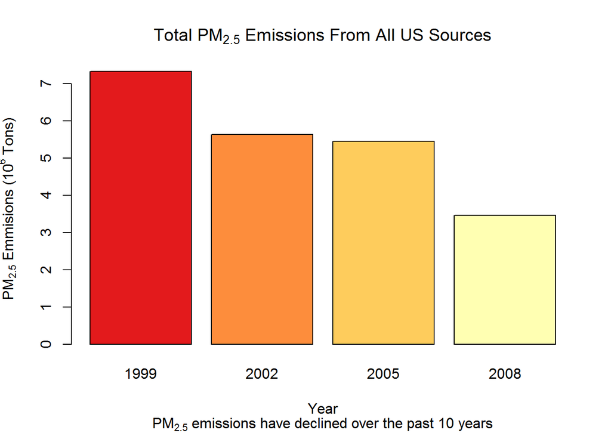

```r
Q1Data <- group_by(allthedata, year) %>% summarise(sumEmissions = sum(Emissions)/1000000)
n <- length(unique(Q1Data$year))
theorder <- order(Q1Data$sumEmissions)
colors <- brewer.pal(n,'YlOrRd')
barplot(Q1Data$sumEmissions,
        names.arg = Q1Data$year,
        xlab = 'Year',
        ylab = expression('PM'[2.5]*' Emmisions (10'^6*' Tons)'),
        main = expression('Total PM'[2.5]*' Emissions From All US Sources'),
        sub = expression('PM'[2.5]*' emissions have declined over the past 10 years'),
        col = colors[theorder])
```

# Question 2

Have total emissions from PM2.5 decreased in the Baltimore City, Maryland (fips == “24510”) from 1999 to 2008? Use the base plotting system to make a plot answering this question.

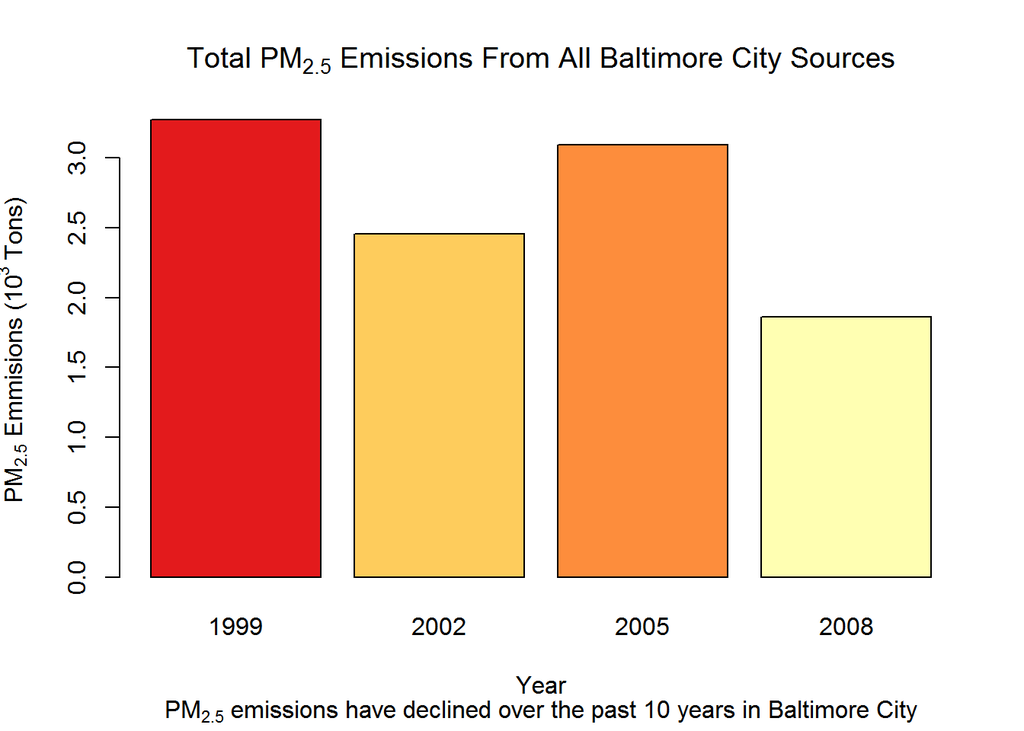

```r
Q2Data <- filter(allthedata, fips == '24510') %>% group_by(year) %>% summarise(sumEmissions = sum(Emissions)/1000)
n <- length(unique(Q2Data$year))
theorder <- order(Q2Data$sumEmissions)
colors <- brewer.pal(n,'YlOrRd')
barplot(Q2Data$sumEmissions,
        names.arg = Q2Data$year,
        xlab = 'Year',
        ylab = expression('PM'[2.5]*' Emmisions (10'^3*' Tons)'),
        main = expression('Total PM'[2.5]*' Emissions From All Baltimore City Sources'),
        sub = expression('PM'[2.5]*' emissions have declined over the past 10 years in Baltimore City'),
        col = colors[theorder])
```

# Question 3

Of the four types of sources indicated by the type (point, nonpoint, onroad, nonroad) variable, which of these four sources have seen decreases in emissions from 1999-2008 for Baltimore City? Which have seen increases in emissions from 1999-2008? Use the ggplot2 plotting system to make a plot answer this question.

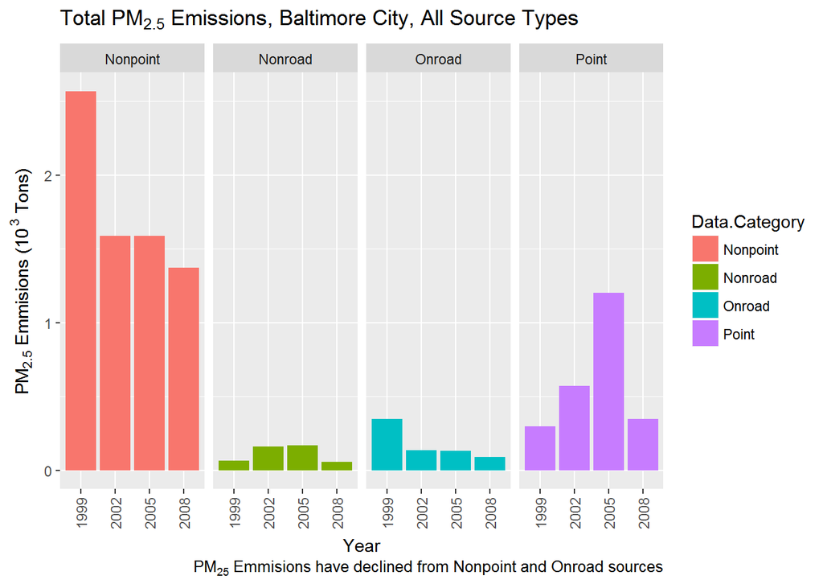

```r
Q3Data <- filter(allthedata, fips == '24510') %>% group_by(Data.Category,year) %>% summarise(sumEmissions = sum(Emissions)/1000) %>% filter(Data.Category != 'Event')

ggplot(Q3Data) +
  geom_col(mapping = aes(x = factor(year), y = sumEmissions, fill = Data.Category), position = 'dodge') +
  facet_grid(. ~ Data.Category) +
  labs(x = 'Year', y = expression('PM'[2.5]*' Emmisions (10'^3*' Tons)'), title = expression('Total PM'[2.5]*' Emissions, Baltimore City, All Source Types')) +
  labs(caption = expression('PM'[25]*' Emmisions have declined from Nonpoint and Onroad sources')) +
  theme(axis.text.x = element_text(angle = 90, vjust = .5))
```

# Question 4

Across the United States, how have emissions from coal combustion-related sources changed from 1999-2008?

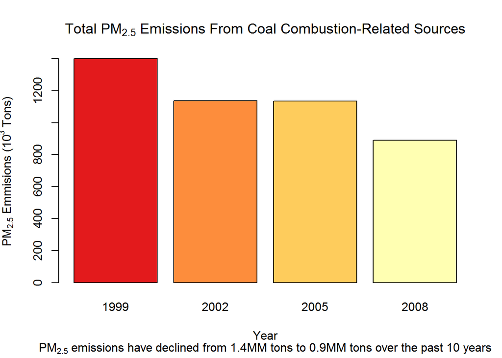

```r
# Subset the data to get to coal combustion
Q4Data <- filter(allthedata, (grepl('comb', allthedata$Short.Name, ignore.case = TRUE) | grepl('coal', allthedata$Short.Name, ignore.case = TRUE)))
Q4Data2 <- Q4Data %>% group_by(year) %>% summarise(sumEmissions = sum(Emissions)/1000)

n <- length(unique(Q4Data2$year))
theorder <- order(Q4Data2$sumEmissions)

barplot(Q4Data2$sumEmissions,
        names.arg = Q4Data2$year,
        xlab = 'Year',
        ylab = expression('PM'[2.5]*' Emmisions (10'^3*' Tons)'),
        main = expression('Total PM'[2.5]*' Emissions From Coal Combustion-Related Sources'),
        sub = expression('PM'[2.5]*' emissions have declined from 1.4MM tons to 0.9MM tons over the past 10 years'),
        col = colors[theorder])
```

# Question 5

How have emissions from motor vehicle sources changed from 1999-2008 in Baltimore City?

[figure not shown]

```r
Q5Data <- filter(allthedata, grepl('Highway Vehicles', allthedata$SCC.Level.Two, ignore.case = TRUE)) %>% group_by(year) %>% summarise(sumEmissions = sum(Emissions)/1000)
# Searching for 'vehicles' in SCC.Level.Two seemed to be fully inclusive of all the naming conventions across other columns.
# I specified 'Highway Vehicles' (filtering out off-highway vehicles) as off-highway vehicles looked to be construction and agricultural equipment

n <- length(unique(Q5Data$year))
theorder <- order(Q5Data$sumEmissions)

barplot(Q5Data$sumEmissions,
        names.arg = Q4Data2$year,
        xlab = 'Year',
        ylab = expression('PM'[2.5]*' Emmisions (10'^3*' Tons)'),
        main = expression('Total PM'[2.5]*' Emissions From Coal Combustion-Related Sources'),
        sub = expression('PM'[2.5]*' emissions rose sharply from 1999-2002, and have steadily increased since'),
        col = colors[theorder])
```

# Question 6

Compare emissions from motor vehicle sources in Baltimore City with emissions from motor vehicle sources in Los Angeles County, California (fips == “06037”). Which city has seen greater changes over time in motor vehicle emissions?

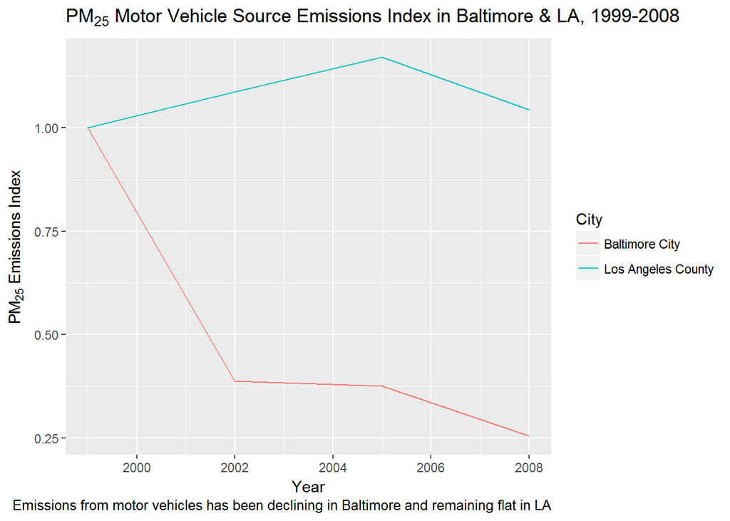

```r
Q6Data <- allthedata %>% filter((fips %in% c('06037','24510')) & grepl('Highway Vehicles', allthedata$SCC.Level.Two, ignore.case = TRUE)) %>% group_by(fips,year) %>% summarise(sumEmissions = sum(Emissions))


allfips <- unique(Q6Data$fips)
startingValue <- NULL
Q6Data2 <- NULL

# I'm going to index the data to 1999 to help better compare relative trends between the two cities
for(i in 1:length(allfips)){
    dataSubset <- filter(Q6Data,fips == allfips[i])
    minYear <- min(dataSubset$year)
    dataSubset2 <- filter(dataSubset, year == minYear)
    startingValue <- dataSubset2$sumEmissions
    dataSubset <- mutate(dataSubset, indexEmissions = sumEmissions/startingValue,
                         City = ifelse(allfips[i] == '06037', 'Los Angeles County',
                                       ifelse(allfips[i] == '24510', 'Baltimore City', NA)))
    Q6Data2 <- rbind(Q6Data2,dataSubset)
}

ggplot(Q6Data2, mapping = aes(x = year, y = indexEmissions, color = City)) +
  geom_line() +
  labs(x = 'Year', y = expression('PM'[25]*' Emissions Index'), title = expression('PM'[25]*' Motor Vehicle Source Emissions Index in Baltimore & LA, 1999-2008'), caption = 'Emissions from motor vehicles has been declining in Baltimore and remaining flat in LA')
```